# Spatial Analyses of wild boars data regarding on psycological patterns

Semester Project for Patterns & Trends in Environmental Data FS22

Authors: Jonas Michael Windisch and Johannes Quente

Submission Date: 03.07.2022

## Introduction

In recent decades, an expansion and increase of wild boar (*Sus scrofa*) populations has been observed across Europe, with colonising agricultural and urban areas, thus increasing problems of cohabitation with humans (Rutten et al., 2020). In particular, the wild boar often comes into conflict with humans, the main problems being the transmission of diseases to domestic animals and humans, collisions with vehicles, disturbance or threat to citizens and damage to gardens, public parks, pasture and agriculture (Meng et al. 2009).

Wild boar damage to croplands is expressed in different ways: direct consumption of crops, rooting in search of bulbs, invertebrates or tubers, seed removal, trampling and damage to agricultural infrastructure (Barrios-García & Ballari 2012). Therefore, it is important to know their activity patterns and where and when the wild boars are in order to take countermeasures.

The research question been asked is: How can the different environments (settlements, streets and different land use categories) been contextualized with the activity-patterns of the wild boars. How can this be conceptualized, modeled and further implemented in suitable visualizations to show behavioral patterns given to a certain environmental context and help to answer questions like “What does wild boar fear?” or “What are the behavioral constraints of wild boars?”.

## Material and Methods

### Data Aquision and Preprosessing

For this project we needed the following data: wild boar data are given by the course administration of Patterns & Trends in Environmental Data, ZHAW, orthoimages & maps are given by swisstopo (open access) and the spatial data are given by geovite.ethz.ch (open access). An overview over the used data is given in table 1.

```r
library(knitr)

data_aquisistion <- data.frame(
  Data = c("Wild-Boar", "Orthophoto", "Map", "TLM_Landcover", "TLM_Streets", "TLM_Railway", "TLM_Building", "TLM_LeisureAreas"),
  Data_Format = c(".csv", ".tif", ".tif", ".geojson", ".geojson", ".geojson", ".geojson", ".geojson"),
  Geometry_Type = c("Points", "Raster", "Raster", "Polygon", "Lines", "Lines", "Polygon", "Polygon"),
  Projected_CRS = c("CH1903+ / LV95", "CH1903 / LV03", "CH1903 / LV03", "WGS 84", "CH1903 / LV03", "CH1903 / LV03", "CH1903 / LV03", "CH1903 / LV03")
)

kable(data_aquisistion, col.names = gsub("[_]", " ", names(data_aquisistion)), caption = "Table 1: Overwiev of the used data for this project")
```

Table 1: Overwiev of the used data for this project

| Data | Data Format | Geometry Type | Projected CRS |
| --- | --- | --- | --- |
| Wild-Boar | .csv | Points | CH1903+ / LV95 |
| Orthophoto | .tif | Raster | CH1903 / LV03 |
| Map | .tif | Raster | CH1903 / LV03 |
| TLM_Landcover | .geojson | Polygon | WGS 84 |
| TLM_Streets | .geojson | Lines | CH1903 / LV03 |
| TLM_Railway | .geojson | Lines | CH1903 / LV03 |
| TLM_Building | .geojson | Polygon | CH1903 / LV03 |
| TLM_LeisureAreas | .geojson | Polygon | CH1903 / LV03 |

After loading the necessary libraries and the data acquisition in R (version 4.2.1), we converted their different coordinate reference system into a consistent one (CH1903+ / LV95). Then, the data are clipped to the study area with the extension of 2’567000/1’202000 to 2’573000/1’207000 with the function `st_intersection()`. The study area is located in the canton of Bern, district Seeland, Commune Gempelen and is located near the lake Neuchâtel. To reduce the amount of data volume - due to hardware limitation - only 7 of 19 wild boars were taken and the time period from 15.12.2014 until the 15.01.2015 was chosen. The result therefore is rather a simplified way to solve our question but includes all the necessary data to answer our research questions.

```r
### Loading Libraries:

library(devtools)
library(ComputationalMovementAnalysisData)
library(ggplot2)
library(readr)
library(dplyr)
library(terra)
library(sf)
library(tmap)
library(SimilarityMeasures)
library(lubridate)
library(tidyr)
library(knitr)


### Data Import:

Wildschwein_sf <- st_as_sf(wildschwein_BE,                            # Convert wild-boar csv-data in Spatial Object
                              coords = c("E", "N"),
                              crs = 2056)
Study_Area <- st_read("StudyArea.geojson")                            # Import Study Area
Orthophoto <- rast("Swissimage_1m_2014.tif")                          # Import Orthophoto as Raster-Data
Map <- terra::rast("Map_1to25000_2018.tif")                                  # Import Map as Raster-Data
Feldfruechte <- st_read("Feldfruechte_1m_2021.geojson")
TLM_Bodenbedeckung <- st_read("TLM_Bodenbedeckung_2020.geojson")      # Import Landcover-Types
TLM_Strassen <- st_read("TLM_Strassen_2020.geojson")                  # Import Roads
TLM_Eisenbahn <- st_read("TLM_Eisenbahn_2020.geojson")                # Import Railway-Lines
TLM_Gebaeude <- st_read("TLM_Gebaeude_Foodprint_2020.geojson")        # Import Buildings
TLM_Freizeitareale <- st_read("TLM_Freizeitareale_2020.geojson")      # Import Leisure-Areas


### Convert CRS:

Wildschwein_sf          # Projected CRS: CH1903+ / LV95
Study_Area              # Projected CRS: CH1903+ / LV95
Orthophoto              # Projected CRS: CH1903 / LV03
Map                     # Projected CRS: CH1903 / LV03
Feldfruechte            # Projected CRS: CH1903+ / LV95
TLM_Bodenbedeckung      # Projected CRS: WGS 84
TLM_Strassen            # Projected CRS: CH1903 / LV03
TLM_Eisenbahn           # Projected CRS: CH1903 / LV03
TLM_Gebaeude            # Projected CRS: CH1903 / LV03
TLM_Freizeitareale      # Projected CRS: CH1903 / LV03

TLM_Bodenbedeckung <- st_transform(TLM_Bodenbedeckung, crs = st_crs(2056))
TLM_Strassen <- st_transform(TLM_Strassen, crs = st_crs(2056))
TLM_Eisenbahn <- st_transform(TLM_Eisenbahn, crs = st_crs(2056))
TLM_Gebaeude <- st_transform(TLM_Gebaeude, crs = st_crs(2056))
TLM_Freizeitareale <- st_transform(TLM_Freizeitareale, crs = st_crs(2056))
Study_Area_for_Raster <- st_transform(Study_Area, crs = st_crs(21781))


### Objektart as Numeric:

TLM_Bodenbedeckung$objektart <- as.numeric(TLM_Bodenbedeckung$objektart)
TLM_Strassen$objektart <- as.numeric(TLM_Strassen$objektart)
TLM_Eisenbahn$objektart <- as.numeric(TLM_Eisenbahn$objektart)
TLM_Gebaeude$objektart <- as.numeric(TLM_Gebaeude$objektart)
TLM_Freizeitareale$objektart <- as.numeric(TLM_Freizeitareale$objektart)


### Downsizing Orthophoto

Orthophoto <- aggregate(Orthophoto, fact=2)

### Clip Data to Study_Area

Wildschwein_sf <- st_intersection(Wildschwein_sf, Study_Area)
Orthophoto <- crop(x = Orthophoto, y = Study_Area_for_Raster)
Feldfruechte <- st_intersection(Feldfruechte, Study_Area)
TLM_Bodenbedeckung <- st_intersection(TLM_Bodenbedeckung, Study_Area)
TLM_Strassen <- st_intersection(Study_Area, TLM_Strassen)
TLM_Eisenbahn <- st_intersection(Study_Area, TLM_Eisenbahn)
TLM_Gebaeude <- st_intersection(Study_Area, TLM_Gebaeude)
TLM_Freizeitareale <- st_intersection(Study_Area, TLM_Freizeitareale)


### Choose Wild-Boar Data from 2014 to 2015

Wildschwein_select <- Wildschwein_sf %>%
  filter(DatetimeUTC >= as.Date("2014-12-15") & DatetimeUTC < as.Date("2015-01-15"))

timespan <- as.numeric(difftime(time1 = "2015-01-15", time2 = "2014-12-15", units = "secs"))


### Add Metadata
### Bodenbedeckung:

objektart <- c(1:15)
objektart_Beschreibung <- c("Fels", "Fels locker", "Felsbloecke", "Felsbloecke locker", "Fliessgewaesser", "Gebueschwald", "Lockergestein", "Lockergestein locker", "Gletscher", "Stehende Gewaesser", "Feuchtgebiet", "Wald", "Wald offen", "Gehoelzflaeche", "Schneefeld Toteis")
Attributnamen <- data.frame(objektart, objektart_Beschreibung)

TLM_Bodenbedeckung <-left_join(TLM_Bodenbedeckung, Attributnamen, by = "objektart")


### Strassen:

objektart <- c(1:23)
objektart_Beschreibung <- c("Ausfahrt", "Einfahrt", "Autobahn", "Raststaette", "Verbindung", "Zufahrt", "Dienstzufahrt", "10m Strasse", "6m Strasse", "4m Strasse", "3m Strasse", "Platz", "Autozug", "Faehre", "2m Weg", "1m Weg", "1m Wegfragment", "2m Wegfragment", "Markierte Spur","8m Strasse","Autostrasse","Klettersteig", "Provisorium")
Attributnamen <- data.frame(objektart, objektart_Beschreibung)

TLM_Strassen <-left_join(TLM_Strassen, Attributnamen, by = "objektart")


### Eisenbahn:

objektart <- c(0,2,4,5)
objektart_Beschreibung <- c("Normalspur", "Schmalspur", "Schmalspur mit Normalspur", "Kleinbahn")
Attributnamen <- data.frame(objektart, objektart_Beschreibung)

TLM_Eisenbahn <-left_join(TLM_Eisenbahn, Attributnamen, by = "objektart")


### Gebaeude:

objektart <- c(0:22)
objektart_Beschreibung <- c("Gebaeude", "NA", "Hochhaus", "Hochkamin", "Turm", "Kuehlturm", "Lagertank", "Lueftungsschacht", "Offenes Gebaeude", "Treibhaus", "Im Bau", "Kapelle", "Sakraler Turm", "Sakrales Gebaeude", "NA", "Flugdach", "Unterirdisches Gebaeude", "Mauer gross", "Mauer gross gedeckt", "Historische Baute", "NA", "NA", "Verbindungsbruecke")
Attributnamen <- data.frame(objektart, objektart_Beschreibung)

TLM_Gebaeude <-left_join(TLM_Gebaeude, Attributnamen, by = "objektart")


### Freizeitareale:

objektart <- c(0:7)
objektart_Beschreibung <- c("Campingplatzareal", "Freizeitanlagenareal", "Golfplatzareal", "Pferderennbahnareal", "Schwimmbadareal", "Sportplatzareal", "Standplatzareal", "Zooareal")
Attributnamen <- data.frame(objektart, objektart_Beschreibung)

TLM_Freizeitareale <-left_join(TLM_Freizeitareale, Attributnamen, by = "objektart")
```

### The most fearful and the most brave wild boar

To describe the effect of the human influence areas at the activity-patterns of the wild boars, the question was asked: What is the most fearful and the most brave wild boar? The “fearful” wild boar is defined as the animal which avoids urban areas. The “brave” wild boar is the one that ventures closest to settlements. The ranking was based on the time spent in human influence areas as a percentage over the entire study period (31 days).

To define the human influence areas - such as streets, railway, building and leisure areas - the data sets were first combined by `union()`. Then a buffer zone of 100 m was created around the human influence areas (`buffer()`). This range corresponds to the escape distance of 100 m to 200 m of wild boars given in the literature (Suter et al., 2018; Thurfjell et al. 2013). After joining the wild boar data with the Human Influence Areas Buffers (`st_join()`), the time difference between subsequent rows was calculated with `difftime()`. All categories of the urban areas were combined and named “Human Influence Areas” and all natural environment as “Nature”. In Figure 1 a) are all human influence areas in the study area shown and in b) the 100 m buffer zone around the human influence areas.

```r
### Combine Human Influence Areas.
### Geometry Type: Lines

Strassen_kl <- TLM_Strassen[,c("objektart_Beschreibung", "geometry")]
Eisenbahn_kl <- TLM_Eisenbahn[,c("objektart_Beschreibung", "geometry")]

Lines <- union(Strassen_kl, Eisenbahn_kl)
Lines <- st_as_sf(Lines)


### Geometry Type: Polygons

Gebaeude_kl <- TLM_Gebaeude[,c("objektart_Beschreibung", "geometry")]
Freizeitareale_kl <- TLM_Freizeitareale[,c("objektart_Beschreibung", "geometry")]

Polygons <- union(Gebaeude_kl, Freizeitareale_kl)
Polygons <- st_as_sf(Polygons)


### Total Human Influence Areas.

Human_Influence_Areas <- union(Lines, Polygons)
Human_Influence_Areas <- st_as_sf(Human_Influence_Areas)


### Create Buffer around Human Influence Areas.

Human_Influence_Areas_Buffer <- st_buffer(x = Human_Influence_Areas, dist = 100)


### Plot Human Influence Areas

Human_Influence_Areas_Plot <- tm_shape(shp = Orthophoto) +
    tm_rgb() +
  tm_shape(shp = Wildschwein_select) +
    tm_dots(col = "TierName") +
  tm_shape(shp = Human_Influence_Areas) +
    tm_polygons(col = "objektart_Beschreibung") +
    tm_lines(col = "objektart_Beschreibung") +
  tm_compass(type = "arrow", position = c(0.247,0.028), bg.color = "white", bg.alpha = 0.75, size = 1.8) +
  tm_scale_bar(breaks = c(0, 0.25, 0.5, 0.75 ,1), text.size = 0.75, position = c("left", "bottom"), bg.color = "white", bg.alpha = 0.75) +
  tm_layout(main.title = "a)",
            main.title.size = 1,
            legend.title.size = 1,
            legend.title.color = "white",
            legend.text.size = 0.6,
            legend.outside = TRUE,
            legend.bg.color = "white",
            legend.bg.alpha = 1)

Human_Influence_Areas_Buffer <- mutate(Human_Influence_Areas_Buffer,Human_Influence_Areas =  "Human Influence Areas")

Human_Influence_Areas_Buffer_Plot <- tm_shape(shp = Orthophoto) +
    tm_rgb() +
  tm_shape(shp = Human_Influence_Areas_Buffer) +
    tm_polygons(col = "Human_Influence_Areas", palette = "grey") +
  tm_shape(shp = Wildschwein_select) +
    tm_dots(col = "TierName") +
    tm_compass(type = "arrow", position = c(0.247,0.028), bg.color = "white", bg.alpha = 0.75, size = 1.8) +
  tm_scale_bar(breaks = c(0, 0.25, 0.5, 0.75 ,1), text.size = 0.75, position = c("left", "bottom"), bg.color = "white", bg.alpha = 0.75) +
  tm_layout(main.title = "b)",
            main.title.size = 1,
            legend.title.size = 1,
            legend.title.color = "white",
            legend.text.size = 0.6,
            legend.outside = TRUE,
            legend.bg.color = "white",
            legend.bg.alpha = 1)


### most fearful/brave wild boar

Wildboar_brave <- st_join(x = Wildschwein_select, y = Human_Influence_Areas_Buffer)

Wildboar_brave$objektart_Beschreibung <- replace_na(data = Wildboar_brave$objektart_Beschreibung, replace = "Wald&Wiesen&Natur")

Wildboar_brave <- mutate(Wildboar_brave, Human_Influence_Areas = if_else(objektart_Beschreibung == "Wald&Wiesen&Natur", "Nature", "Human_Influence_Areas"))

Wildboar_brave <- st_drop_geometry(Wildboar_brave)

Wildboar_brave <- mutate(Wildboar_brave,time_of_stay = as.integer(difftime(time1 = lead(DatetimeUTC), time2 = DatetimeUTC), units = "secs"))

Wildboar_brave <- Wildboar_brave[,c("TierName", "objektart_Beschreibung", "time_of_stay", "Human_Influence_Areas")]

Wildboar_brave_list <-  Wildboar_brave %>%
  filter(time_of_stay >0) %>%
  group_by(TierName, Human_Influence_Areas) %>%
  summarise(time_of_stay_s = sum(time_of_stay)) %>%
  mutate(time_of_stay_percent = (time_of_stay_s/timespan)*100)
```

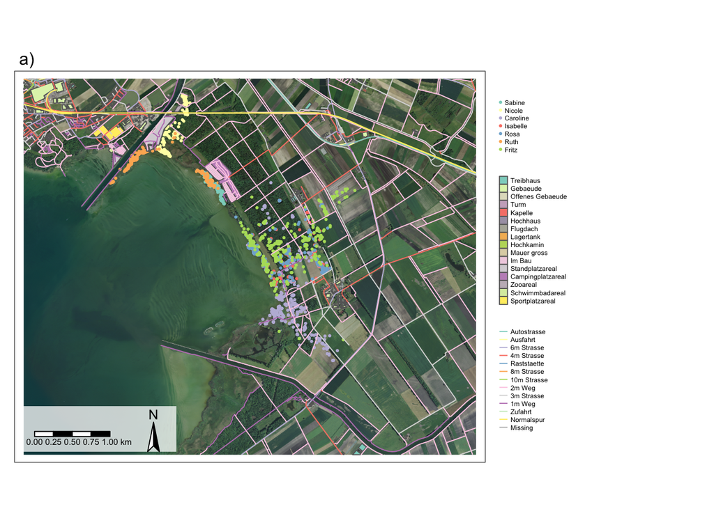

```r
Human_Influence_Areas_Plot
```

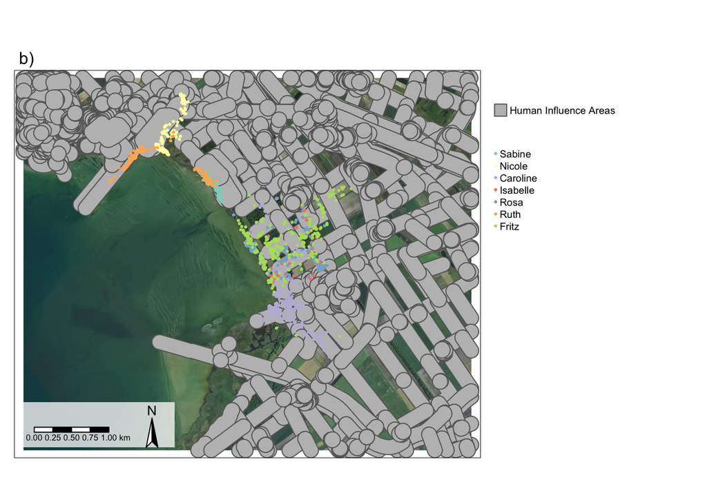

Figure 1: a) all human influence areas in the study area; b) the 100 m buffer zone around the human influence areas.

```r
Human_Influence_Areas_Buffer_Plot
```

## Results

### The most fearful and the most brave wild boar

The effect of the human influence areas at the activity-patterns of the wild boars is shown in Figure 2. The duration of stay in urban areas is different for each animal. It is clearly seen, that the wild boars “Sabine” and “Ruth” venture closest to settlements. Whereas “Isabelle” and “Rosa” avoid the human influence areas and and prefer to stay in nature. The exact values and the ranking for each wild boar are given in table 2 & 3.

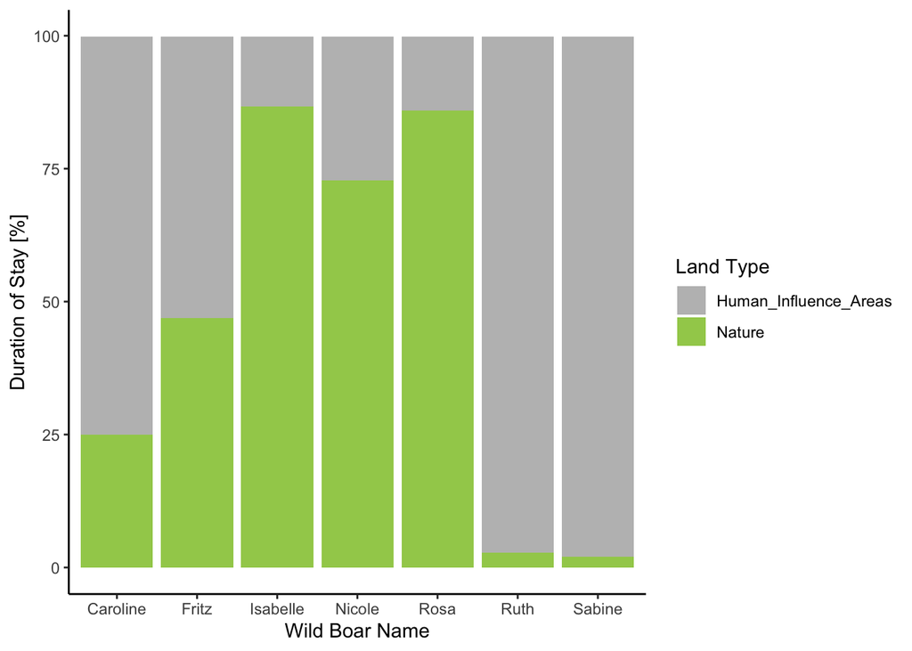

Figure 2: Time stay in human influence areas and nature as a percentage over the entire study period (31 days) of the seven wild boars.

```r
# Plot
Wildboar_brave_list_plot <- ggplot(Wildboar_brave_list, aes(x = TierName, y = time_of_stay_percent, fill = Human_Influence_Areas)) +
  geom_col() +
  theme_classic() +
  labs(y = "Duration of Stay [%]", x = "Wild Boar Name") +
  guides(fill=guide_legend(title="Land Type")) +
  scale_fill_manual(values = c("grey", "darkolivegreen3"))
Wildboar_brave_list_plot
```

```r
# Ranking brave
Wildboar_brave_rank <- Wildboar_brave_list %>%
  group_by(TierName) %>%
  filter(Human_Influence_Areas == "Human_Influence_Areas") %>%
  arrange(desc(time_of_stay_percent))
Wildboar_brave_rank$Rank <- 1:nrow(Wildboar_brave_rank)
Wildboar_brave_rank$Tier_Name <- Wildboar_brave_rank$TierName
Wildboar_brave_rank$Duration_of_Stay <- Wildboar_brave_rank$time_of_stay_percent
Wildboar_brave_rank <- Wildboar_brave_rank[,c("Tier_Name", "Duration_of_Stay", "Rank")]
Wildboar_brave_rank$Duration_of_Stay <- round(Wildboar_brave_rank$Duration_of_Stay, digits = 0)

kable(Wildboar_brave_rank, col.names = gsub("[_]", " ", names(Wildboar_brave_rank)), caption = "Table 2: The exact values and the ranking for the brave wild boar (Duration of Stay in Percent)")
```

Table 2: The exact values and the ranking for the brave wild boar (Duration of Stay in Percent)

| Tier Name | Duration of Stay | Rank |
| --- | --- | --- |
| Sabine | 98 | 1 |
| Ruth | 97 | 2 |
| Caroline | 75 | 3 |
| Fritz | 53 | 4 |
| Nicole | 27 | 5 |
| Rosa | 14 | 6 |
| Isabelle | 13 | 7 |

```r
# Ranking fearful
Wildboar_fearful_rank <- Wildboar_brave_list %>%
  group_by(TierName) %>%
  filter(Human_Influence_Areas == "Nature") %>%
  arrange(desc(time_of_stay_percent))
Wildboar_fearful_rank$Rank <- 1:nrow(Wildboar_fearful_rank)
Wildboar_fearful_rank$Tier_Name <- Wildboar_fearful_rank$TierName
Wildboar_fearful_rank$Duration_of_Stay <- Wildboar_fearful_rank$time_of_stay_percent
Wildboar_fearful_rank <- Wildboar_fearful_rank[,c("Tier_Name", "Duration_of_Stay", "Rank")]
Wildboar_fearful_rank$Duration_of_Stay <- round(Wildboar_fearful_rank$Duration_of_Stay, digits = 0)

kable(Wildboar_fearful_rank, col.names = gsub("[_]", " ", names(Wildboar_fearful_rank)), caption = "Table 2: The exact values and the ranking for the fearful wild boar (Duration of Stay in Percent)")
```

| Tier Name | Duration of Stay | Rank |
| --- | --- | --- |
| Isabelle | 87 | 1 |
| Rosa | 86 | 2 |
| Nicole | 73 | 3 |
| Fritz | 47 | 4 |
| Caroline | 25 | 5 |
| Ruth | 3 | 6 |
| Sabine | 2 | 7 |

## Bibliography

M. Noelia Barrios-Garcia, Sebastian A. Ballari, “Impact of wild boar (Sus scrofa) in its introduced and native range: a review”, Biol Invasions, vol, 14, pp. 2283–2300, 2012, https://link.springer.com/content/pdf/10.1007/s10530-012-0229-6.pdf.

X. J. Meng, D. S. Lindsay, and N. Sriranganathan, “Wild boars as sources for infectious diseases in livestock and humans”, Philosophical Transactions of the Royal Society B: Biological Sciences, vol. 364, no. 1530, pp. 2697–2707, 2009, https://www.ncbi.nlm.nih.gov/pmc/articles/PMC2865094/pdf/rstb20090086.pdf.

Anneleen Rutten, Jim Casaer, Diederik Strubbe and Herwig Leirs, “Agricultural and landscape factors related to increasing wild boar agricultural damage in a highly anthropogenic landscape”, Wildlife Biology, vol. 2020, no. 1, pp. 1-11, 2020, https://onlinelibrary.wiley.com/doi/pdf/10.2981/wlb.00634.

Suter Stefan, Sandro Stoller & Benjamin Sigrist, “Prävention von Wildschweinschäden in der Landwirtschaft und Management von Wildschweinen in Schutzgebieten”, Schlussbericht, 2018, https://www.zhaw.ch/storage/hochschule/medien/bildmaterial/Schlussbericht_Wildschweinschreck.pdf.